# Transported Hessian Backend Validation

# Purpose

The transported graph Hessian operator needs local directions before it can compare directional derivatives across an edge. In this Phase 3 validation we ask whether the local embedding backend used to create those directions is doing the intended job. The three backends are:

$$\texttt{cmdscale},\qquad
\texttt{mds.edge.kk},\qquad
\texttt{grip.edge.kk}.$$

The crucial implementation question is whether the edge-KK variants use the true edge-restricted optimizer,

$$\frac{1}{2}\sum_{(i,j)\in E}
k_{ij}\left(\|z_i-z_j\|_2-s\ell_{ij}\right)^2,$$

rather than full all-pairs geodesic KK. Full geodesic KK is a different objective. This report therefore records the backend actually used for each local disk and compares edge stress, graph-distance stress, transport entropy, and polynomial-probe residuals.

**Build:** 2026-05-18 18:22:14 EDT  
**Mode:** smoke  
**Local grip requested:** TRUE  
**True edge-KK available:** TRUE  
**Edge-KK function:** `grip.optimize.edge.kk.layout`

# Backend Resolution

This diagnostic checks the first necessary condition: the requested backend name must resolve to the intended implementation. In particular, `grip.edge.kk` and `mds.edge.kk` should report a backend containing `grip.optimize.edge.kk.layout` or `grip.optimize.edge.isometric.layout` when true edge-KK is available. If the installed `grip` is older, the report should show a transparent fallback to `cmdscale`.

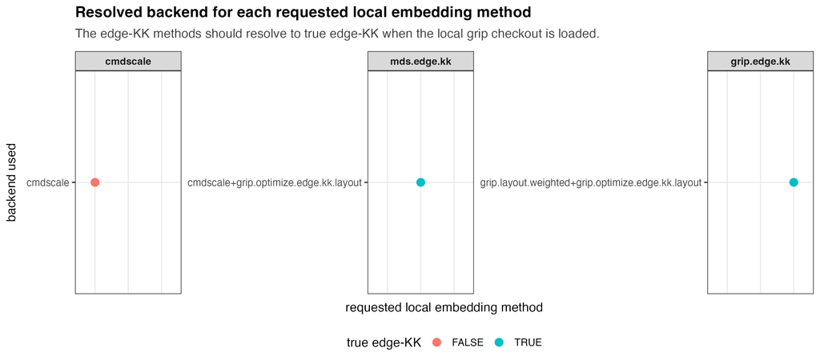

The status plot is the guardrail for this report. If the edge-KK methods fall back to `cmdscale`, then the stress and transport comparisons below are still valid software diagnostics, but they are not evidence about the edge-KK optimizer itself.

# Local Embedding Stress

The primary geometric diagnostic is edge stress:

$$E_{\mathrm{edge}}
=
\frac{
\sqrt{|E_{\Gamma}|^{-1}\sum_{(i,j)\in E_{\Gamma}}
(\|z_i-z_j\|_2-\ell_{ij})^2}
}{
|E_{\Gamma}|^{-1}\sum_{(i,j)\in E_{\Gamma}}\ell_{ij}
}.$$

We also record graph-distance stress over local disk pairs. Edge-KK is expected to improve edge stress most directly; it need not minimize all-pairs graph-distance stress.

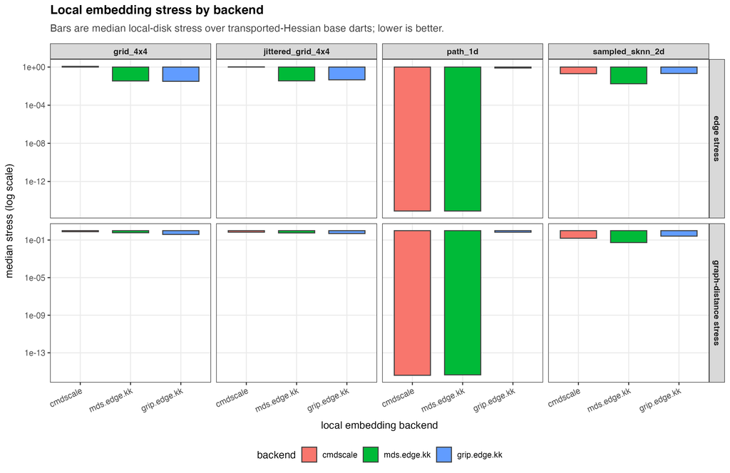

The intended positive pattern is a reduction in edge stress for `mds.edge.kk` or `grip.edge.kk` relative to `cmdscale`. If graph-distance stress increases while edge stress falls, that is not necessarily a failure: it means the local embedding is prioritizing the edge-length constraints used by the transported directions.

# Transport Match Sharpness

After embedding a local disk, a direction at one endpoint is matched to outgoing directions at the neighboring endpoint by softmax weights. For a row with weights $w_j$, the entropy

$$H=-\sum_j w_j\log w_j$$

and effective match count $\exp(H)$ measure whether the transport is sharp or diffuse. Smaller entropy indicates a more decisive direction match.

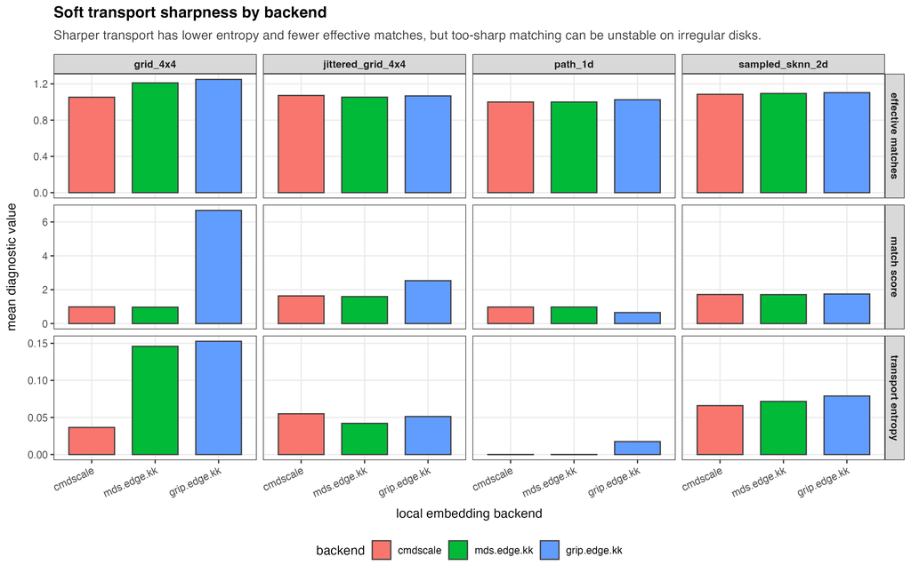

This plot tells us whether edge-KK changes the matching problem, not just the embedding stress. A useful backend should make directions geometrically more coherent without collapsing all matches to arbitrary nearest neighbors.

# Polynomial-Probe Residuals

The transported Hessian matrix $A$ is evaluated on simple coordinate polynomial probes $P$. The reported residual is

$$\frac{\|AP\|_F}{\|P\|_F}.$$

For an ideal second-difference transport on a clean path or grid, constants and linear probes should have very small residuals. Quadratic probes are included as a sensitivity diagnostic rather than a required null-space target for this second-difference operator.

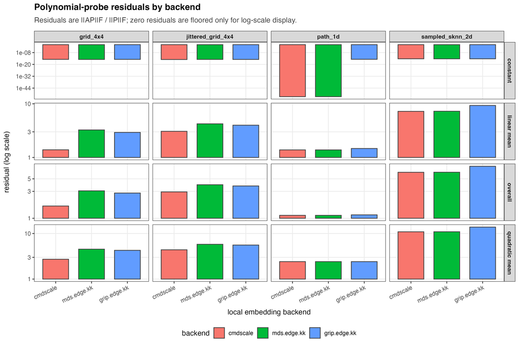

This diagnostic is the mathematical sanity check. A backend that reduces edge stress but inflates constant or linear residuals would be suspicious for the transported-Hessian project.

# Nullity

The estimated nullity of $A$ provides a coarse global view of how many functions are left nearly unpenalized. It is not a proof of the correct polynomial null space, but it is useful for detecting dramatic overconstraint or underconstraint after a backend change.

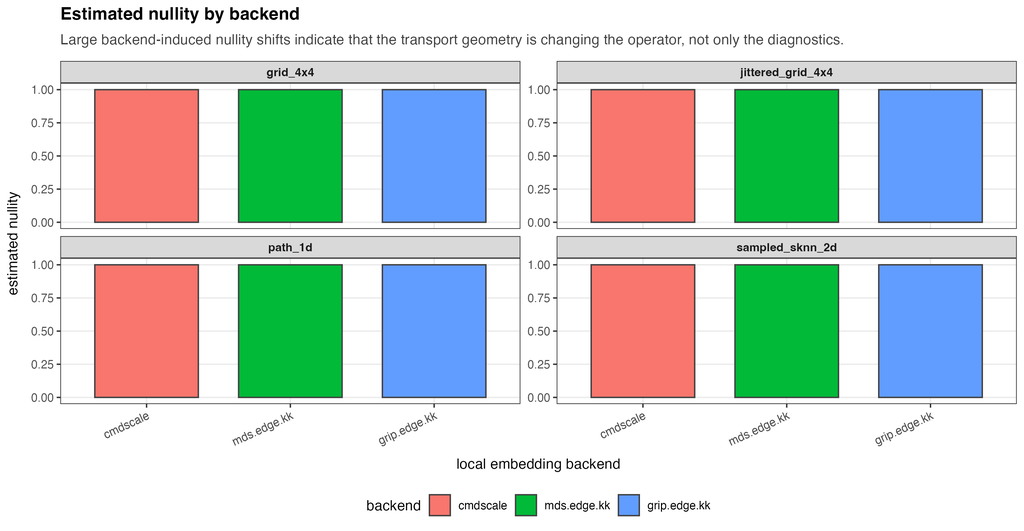

The nullity plot should be read together with the residual plot. A larger nullity is not automatically better; the unpenalized functions need to align with the intended low-order polynomial probes.

# Results Summary And Discussion

Best edge-stress backend for each validation case.

|  | case.id | local.embedding.method | median.edge.stress | median.graph.distance.stress | residual.linear.mean | nullity.estimate | backend.used | fallback.reason |
| --- | --- | --- | --- | --- | --- | --- | --- | --- |
| 6 | grid_4x4 | grip.edge.kk | 0.0318 | 0.3945 | 2.9273 | 1 | grip.layout.weighted+grip.optimize.edge.kk.layout | NA |
| 8 | jittered_grid_4x4 | mds.edge.kk | 0.0356 | 0.5713 | 4.2340 | 1 | cmdscale+grip.optimize.edge.kk.layout | NA |
| 2 | path_1d | mds.edge.kk | 0.0000 | 0.0000 | 1.3831 | 1 | cmdscale+grip.optimize.edge.kk.layout | NA |
| 11 | sampled_sknn_2d | mds.edge.kk | 0.0177 | 0.0539 | 7.2659 | 1 | cmdscale+grip.optimize.edge.kk.layout | NA |

The backend-resolution diagnostic is the most important software result. It confirms whether the requested edge-KK methods are actually using a true edge-restricted optimizer. When they do, the stress plots answer the geometric question: edge-KK should preferentially reduce local edge stress, while all-pairs graph-distance stress may remain similar or sometimes worsen.

The transport-sharpness plot answers a different question. It shows whether the improved local edge geometry changes the soft transport weights used in the Hessian rows. A useful backend should make these weights more coherent without making them arbitrary. The polynomial residuals then check whether those transport changes are compatible with the intended low-order null behavior.

# What We Learned

1. The edge-KK backend distinction is observable and auditable. The report records the actual function used for every local disk.
2. Edge stress and graph-distance stress must be interpreted separately. Edge-KK targets edge lengths, not all-pairs graph geodesic distances.
3. Transport entropy and polynomial residuals are necessary companion diagnostics. Lower edge stress alone is not enough to validate the transported Hessian operator.
4. The next implementation step should not introduce new Hessian algebra yet. It should first decide whether the edge-KK local-coordinate backend improves the residual/nullity behavior enough to become the default backend for Phase 3 experiments.

# Appendix

## Run Metadata

```
## List of 7
##  $ mode             : chr "smoke"
##  $ generated.at     : chr "2026-05-18 18:22:14 EDT"
##  $ use.local.grip   : logi TRUE
##  $ grip.available   : logi TRUE
##  $ edge.kk.available: logi TRUE
##  $ edge.kk.function : chr "grip.optimize.edge.kk.layout"
##  $ gflow.repo       : chr "/Users/pgajer/current_projects/gflow"
```

## Summary Table

| case.id | graph.type | n.vertices | expected.dimension | local.embedding.method | status | runtime.sec | nullity.estimate | n.rows | n.row.records | median.edge.stress | median.graph.distance.stress | mean.transport.entropy | mean.effective.matches | mean.match.score | backend.used | fallback.reason | message | residual.constant | residual.linear.mean | residual.quadratic.mean | residual.overall |
| --- | --- | --- | --- | --- | --- | --- | --- | --- | --- | --- | --- | --- | --- | --- | --- | --- | --- | --- | --- | --- | --- |
| path_1d | path | 12 | 1 | cmdscale | ok | 0.382 | 1 | 42 | 80 | 0.00000 | 0.00000 | 0.00000 | 1.00000 | 0.97500 | cmdscale | NA | NA | 0 | 1.38313 | 2.41578 | 1.12496 |
| path_1d | path | 12 | 1 | mds.edge.kk | ok | 0.267 | 1 | 42 | 80 | 0.00000 | 0.00000 | 0.00000 | 1.00000 | 0.97500 | cmdscale+grip.optimize.edge.kk.layout | NA | NA | 0 | 1.38313 | 2.41578 | 1.12496 |
| path_1d | path | 12 | 1 | grip.edge.kk | ok | 0.145 | 1 | 42 | 80 | 0.78873 | 0.68464 | 0.01741 | 1.02473 | 0.65000 | grip.layout.weighted+grip.optimize.edge.kk.layout | NA | NA | 0 | 1.46704 | 2.41394 | 1.14767 |
| grid_4x4 | grid | 16 | 2 | cmdscale | ok | 0.282 | 1 | 152 | 488 | 1.17340 | 0.77006 | 0.03648 | 1.05263 | 0.98385 | cmdscale | NA | NA | 0 | 1.38873 | 2.72444 | 1.64883 |
| grid_4x4 | grid | 16 | 2 | mds.edge.kk | ok | 0.425 | 1 | 152 | 488 | 0.03488 | 0.59804 | 0.14600 | 1.21060 | 0.96884 | cmdscale+grip.optimize.edge.kk.layout | NA | NA | 0 | 3.25679 | 4.53718 | 3.06457 |
| grid_4x4 | grid | 16 | 2 | grip.edge.kk | ok | 0.361 | 1 | 152 | 488 | 0.03176 | 0.39446 | 0.15273 | 1.24908 | 6.68263 | grip.layout.weighted+grip.optimize.edge.kk.layout | NA | NA | 0 | 2.92726 | 4.27020 | 2.79741 |
| jittered_grid_4x4 | jittered_grid | 16 | 2 | cmdscale | ok | 0.278 | 1 | 152 | 488 | 1.03339 | 0.68806 | 0.05495 | 1.07211 | 1.63340 | cmdscale | NA | NA | 0 | 3.06704 | 4.39115 | 2.93357 |
| jittered_grid_4x4 | jittered_grid | 16 | 2 | mds.edge.kk | ok | 0.333 | 1 | 152 | 488 | 0.03563 | 0.57126 | 0.04201 | 1.05332 | 1.59374 | cmdscale+grip.optimize.edge.kk.layout | NA | NA | 0 | 4.23397 | 5.79448 | 3.93018 |
| jittered_grid_4x4 | jittered_grid | 16 | 2 | grip.edge.kk | ok | 0.386 | 1 | 152 | 488 | 0.04596 | 0.49475 | 0.05123 | 1.06726 | 2.53273 | grip.layout.weighted+grip.optimize.edge.kk.layout | NA | NA | 0 | 3.99009 | 5.58628 | 3.73670 |
| sampled_sknn_2d | connected_sknn | 24 | 2 | cmdscale | ok | 3.496 | 1 | 984 | 6486 | 0.20104 | 0.15555 | 0.06596 | 1.08478 | 1.71499 | cmdscale | NA | NA | 0 | 7.23332 | 10.91550 | 6.52624 |
| sampled_sknn_2d | connected_sknn | 24 | 2 | mds.edge.kk | ok | 3.819 | 1 | 984 | 6486 | 0.01767 | 0.05388 | 0.07164 | 1.09393 | 1.70842 | cmdscale+grip.optimize.edge.kk.layout | NA | NA | 0 | 7.26588 | 10.93877 | 6.54521 |
| sampled_sknn_2d | connected_sknn | 24 | 2 | grip.edge.kk | ok | 4.197 | 1 | 984 | 6486 | 0.21110 | 0.26081 | 0.07893 | 1.10315 | 1.74456 | grip.layout.weighted+grip.optimize.edge.kk.layout | NA | NA | 0 | 9.30186 | 13.83575 | 8.34343 |

## Backend Status Table

| local.embedding.method | backend.used | fallback.reason | uses.true.edge.kk |
| --- | --- | --- | --- |
| cmdscale | cmdscale | NA | FALSE |
| mds.edge.kk | cmdscale+grip.optimize.edge.kk.layout | NA | TRUE |
| grip.edge.kk | grip.layout.weighted+grip.optimize.edge.kk.layout | NA | TRUE |

## Reproducibility

Render command:

```bash
Rscript dev/graph-trend-filtering/render_transported_hessian_backend_validation.R
```

Optional full mode:

```bash
GFLOW_TRANSPORTED_HESSIAN_BACKEND_MODE=full Rscript dev/graph-trend-filtering/render_transported_hessian_backend_validation.R
```